# Data Science Capstone Milestone Report: Exploratory Analysis of the SwiftKey Dataset

Joseph DePasquale

December 2015

### Project Synopsis

For this project we will be working with the concept of Natural Language Processing (NLP).

Around the world, people are spending an increasing amount of time on their mobile devices for email, social networking, banking and a whole range of other activities. But typing on mobile devices can be a serious pain. SwiftKey, our corporate partner in this capstone, builds a smart keyboard that makes it easier for people to type on their mobile devices. One cornerstone of their smart keyboard is predictive text models. When someone types:

“I went to the”

the keyboard presents three options for what the next word might be. For example, the three words might be gym, store, restaurant.

The motivation for this report (from the Coursera website):

1. Demonstrate that you’ve downloaded the data and have successfully loaded it in.
2. Create a basic report of summary statistics about the data sets.
3. Report any interesting findings that you amassed so far.
4. Get feedback on your plans for creating a prediction algorithm and Shiny app.

### Dataset

The data is from a corpus called HC Corpora http://www.corpora.heliohost.org. See the readme file at http://www.corpora.heliohost.org/aboutcorpus.html for details on the corpora available. The files have been language filtered but may still contain some foreign text. The data can be found at https://d396qusza40orc.cloudfront.net/dsscapstone/dataset/Coursera-SwiftKey.zip

```r
# Download data
url  <- "https://d396qusza40orc.cloudfront.net/dsscapstone/dataset/Coursera-SwiftKey.zip"
file <- "Coursera-SwiftKey.zip"
if (!file.exists(file)){
  download.file(url, destfile=file)
}

# Unzip data
if (!dir.exists("final/en_US")) {
  unzip(file)
}

# Read in blogs data
setwd("final/en_US")
con <- file("en_US.blogs.txt")
blogs <- readLines(con)
close(con)

# Read in news data
con <- file("en_US.news.txt", open="rb")
news <- readLines(con)
close(con)

# Read in twitter data
con <- file("en_US.twitter.txt")
twitter <- readLines(con)
close(con)
rm(con)
setwd("../..")
```

### Data Statistics

Before we apply any processing techniques we will provide some statistics about the raw data.

| File | Size (MB) | Number of Lines | Total words |
| --- | --- | --- | --- |
| en_US.blogs.txt | 210.160014 | 899288 | 39386844 |
| en_US.news.txt | 205.811889 | 1010242 | 36876910 |
| en_US.twitter.txt | 167.105338 | 2360148 | 32874008 |

At the recommendation of the course advisors we will now sample the data before we apply any processing techniques.

```r
set.seed(1738)
blogs_Sample <- sampleData(blogs,percent = 0.02)
news_Sample <- sampleData(news,percent = 0.02)
twitter_Sample <- sampleData(twitter,percent = 0.02)
```

Below we provide a snapshot of the sampled raw data. We can see that we have numbers and some foreign characters that must be removed. We can also see that the raw data contains extra white space which is unnecessary.

```r
library(tm, verbose = FALSE)
load("sampledData.RData")

rawSample <- c(blogs_Sample,news_Sample,twitter_Sample)

grep("[[:digit:]]",rawSample, value=TRUE)[1:2]
```

```
## [1] "6. Adam Raised a Cain- Bruce Springsteen"
## [2] "So, without further delay, here's the roll call for my character's I grew up with, probably around age 8 to age 15. There were many more, of course, but these are some that I remember..."
```

```r
grep("[[:cntrl:]]",rawSample, value=TRUE)[1:2]
```

```
## [1] "The âchurnâ refers to the butter churn, or the mixing container, and the âdashâ is the stirring stick. See how the churn dash quilt block looks like the picture of the cross-shaped dash inside of the cylinder churn!? The quilter that named that block obviously spent some time churning her ow…
## [2] "Thatâs absolutely not true."
```

### Data Preprocessing and Cleaning

Below we define the function ‘genCorpus’ that allows us to pass in data and returns clean data. The following actions are performed in this function:

- Upper case letters are converted to lower case (Tree converted to tree)
- Punctuation is removed (don’t converted to dont)
- Numbers and foreign characters (letters with accents, symbols) are removed
- Stopwords are removed (common words: I, I’m, If)
- Profanity is removed
- Extra space is removed

```r
genCorpus <- function(tmpData) {

  # Create Corpus with data provided
  tmpData <- VCorpus(VectorSource(tmpData))

  # Convert all characters to lower case
  tmpData <- tm_map(tmpData, content_transformer(tolower))

  # Remove punction
  tmpData <- tm_map(tmpData, removePunctuation)

  # Remove numbers or foreign characters with blank space.
  tmpData <- tm_map(tmpData, function(x) gsub("[^a-z ]", "", x))

  # Remove stopwords
  tmpData <- tm_map(tmpData, removeWords, stopwords("english"))

  # Remove profanity
  load("profanity.RData")
  tmpData <- tm_map(tmpData, removeWords, profanity)

  # Remove extra white space
  tmpData <- tm_map(tmpData, stripWhitespace)

  # Convert all data to 'PlainTextDocument' to avoid errors using 'tm' package
  tmpData <- tm_map(tmpData, PlainTextDocument)

  return(tmpData)
}
```

Using the genCorpus function we obtain a clean set of data. Next we create a DocumentTermMatrix with the text mining (tm) package. This matrix describes the frequency of terms that occur in a collection of documents. The rows are seperate documents and the columns are word frequencies.

Next we remove words that occur infrequently, sort the data, and convert the data into a data frame for ease of processing with the ggplot2 package.

```r
source("genCorpus.R")

# Create clean data
dataCorclean <- genCorpus(rawSample)

# Create document term matrix
dtm <- DocumentTermMatrix(dataCorclean)

# Remove sparse words
dtm <- removeSparseTerms(dtm , 0.9985)

# Sort word frequencies in descending order
dtmSort <- sort(colSums(as.matrix(dtm)), decreasing = TRUE)

# Convert word frequencies to data frame
wordFreq <- data.frame(term=names(dtmSort[1:20]),occurrences=dtmSort[1:20])

# Clear variables in memory
rm(dtm, rawSample)
```

### Word Frequencies

In the plot below we find the top 20 word frequencies in our dataset. We should note that 7 of 20 most common words contain 3 letters.

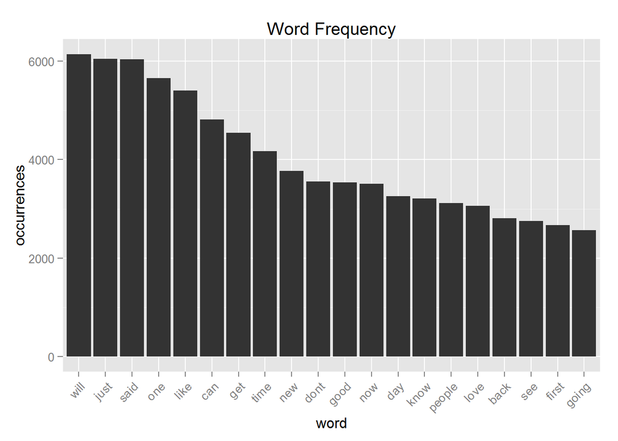

For comparison we provide a plot showing the top 20 word frequencies requiring the length of word is between 4 and 20 letters.

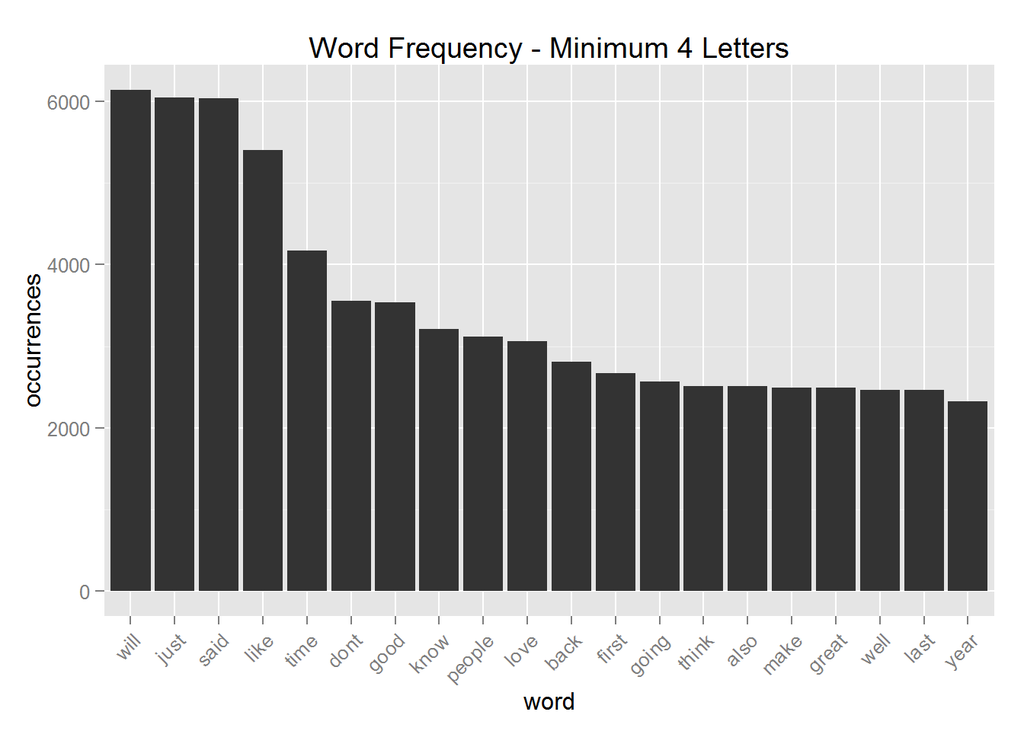

Comparing the two plots above we don’t see any big surprises. All of the words in this plot fairly common. It is worth noting that “don’t” and “can’t” are now interpreted as “dont” and “cant”.

For the purposes of our true end goal (word prediction) we would also like to examine the most frequently occuring word pairs. Examining this plot we can also say that nothing surprising jumps out. From these three plots we can assume our anaylsis is off to a good start. If the word pair “stereo robot” was contained in the top 10 word pairs we would need to evaluate our processing techniques.

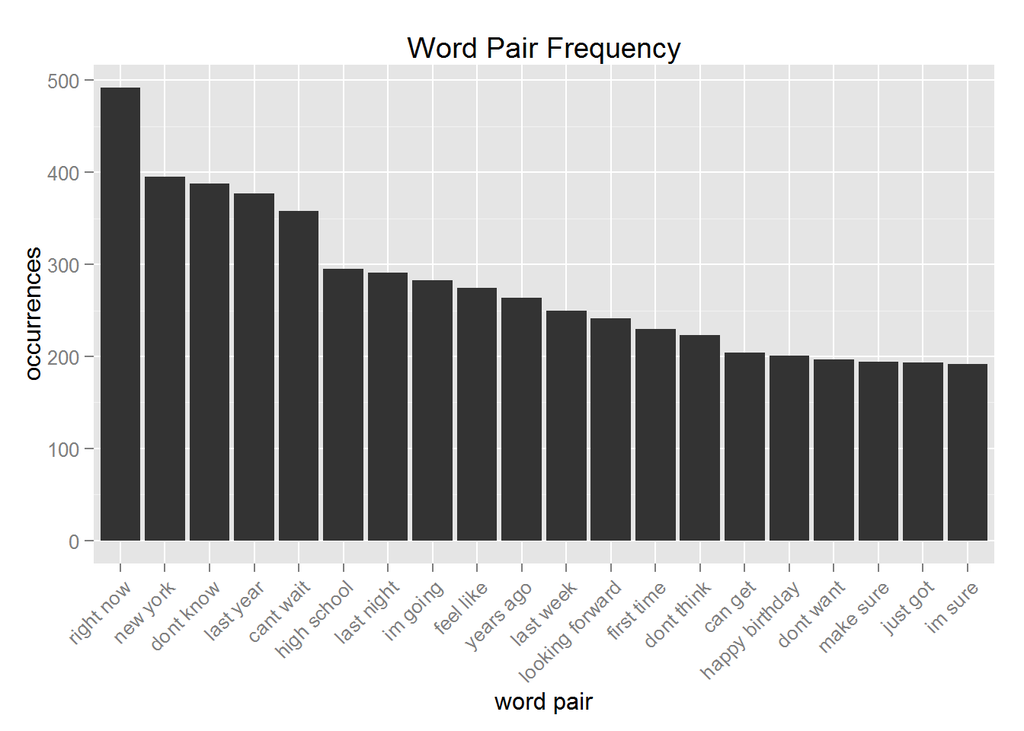

### Future Work

Below is a rough outline of the project. Steps 1 through 3 are complete. Depending on the complexity of our word prediction we may need a higher sampling rate to accumulate more data to train our model.

1. Load in the data
2. Sample the data
3. Preprocess the data
4. Build n-gram frequencies table
5. Use n-gram frequencies table to predict future words